# Sensitivity using Sobol

# Sobol

Sobol sensitivity analysis is similar to LHS approach as a way to efficiently sample parameter space

Sobol is more general - it can use measured parameter samples (we will approximate sampling here by using known distributions but you could use actual samples!)

Sobol is a *variance-based* method

# Sobol Indices - Quantifying Sensitivity

Indices are computed using parameter-output variance relationships; they are estimates so the indices themselves have uncertainty bounds

Several Indices

First order sensitivity or Main Effect

- variance associated directly with parameter alone
- fraction associated with each parameter, sum to 1 (although because it is estimated can be slightly more or less)

Total Effect

- variance associated with parameter and interaction with other parameters
- sum can be more than 1 if parameters interact

Second Order Indices

- less used but quantify how parameter pair-wise parameter interactions contribute to output variation

# Sobol in R

- *Sensitivity* package
- Sobol Indices require estimation - and there are different methods to do that
- The *Sensitivity* package has several of those
- today we will use *sobolSalt* - which uses a method by Saltelli (who has written extensively on Sensitivity analysis)
- R help pages for *Sensitivity* provide many good references
- This is a nice overview paper

[Variance Based Methods](https://www.sciencedirect.com/science/article/pii/S0010465509003087?casa_token=xG4MJV4hwJgAAAAA:Tq_CLHTqtM1wDvhzviZFgm6sVBdOoYzQdFfOGplEi5OUxLSWxaKITce-CzxLxfS6993rNnbK1Q)

# Sobol - how to

- run Sobol to get parameter sets in a sensitivity analysis object
- run model with those parameter sets
- *tell* the senstivity object about results associated with each parameter set
- look at sensitivity analysis indices from Sobol

Generation of parameter sets slightly different

- generate **two** samples of parameter sets by samplng from apriori (expected) distributions
- these would be the “hypothetical” distributions based on assumptions about the data
- ideally these would be distributions that you actually sampled

# Example

Atmospheric Conductance as a function of windspeed, vegetation height and parameters

First lets get the parameters

```r
source("../R/Catm.R")

# generate two examples of random number from parameter distributions

np=1000
k_o = rnorm(mean=0.1,sd=0.1*0.1, n=np)
k_d = rnorm(mean=0.7, sd=0.7*0.1, n=np)
v = rnorm(mean=200, sd=10, n=np)
height = runif(min=5, max=15, n=np)


X1 = cbind.data.frame(k_o, k_d, v, height=height)

# repeat sampling
k_o = rnorm(mean=0.1,sd=0.1*0.1, n=np)
k_d = rnorm(mean=0.7, sd=0.7*0.1, n=np)
v = rnorm(mean=200, sd=10, n=np)
height = runif(min=5, max=15, n=np)

X2 = cbind.data.frame(k_o, k_d, v, height=height)

# there are different versions of sobol functions that have different approaches for estimating parameters and indices, we use an approach implemented by jansen

sens_Catm_Sobol = sobolSalt(model = NULL, X1, X2, nboot = 100)


# Take a look at the Sobol generated sensitivity object
# your parameters sets for sensitivity analysis are in X
```

# Sobol Indices

now run model for Sobol generated parameter sets and compute indices

- pay attention to values of the indices and confidence intervals
  - if 0 is within the confidence interval, parameter uncertainty is not influencing output
- substantial differences between total effect and first order indices suggest parameter interactions

TIP: a useful plotting strategy is to plot model output against parameter with the highest total effect and then use the parameter with second highest total effect for color

```r
# run model for all parameter sets
# make sure you give the parameters names

parms = as.data.frame(sens_Catm_Sobol$X)
colnames(parms)= colnames(X1)
res = pmap_dbl(parms, Catm)


sens_Catm_Sobol = sensitivity::tell(sens_Catm_Sobol,res, res.names="ga")

# main effect:  partitions variance (main effect without co-variance) - sums approximately to one
sens_Catm_Sobol$S
```

```
##       original          bias std. error    min. c.i.  max. c.i.
## X1  0.07127917 -0.0007941518 0.03333037  0.002613989 0.13757781
## X2 -0.01889157 -0.0022598325 0.03110887 -0.082922369 0.04969072
## X3  0.12385696 -0.0042707280 0.03132676  0.068561843 0.18992305
## X4  0.76795144  0.0005272355 0.01025530  0.746800356 0.78851790
```

```r
# useful to add names
row.names(sens_Catm_Sobol$S) = colnames(parms)
sens_Catm_Sobol$S
```

```
##           original          bias std. error    min. c.i.  max. c.i.
## k_o     0.07127917 -0.0007941518 0.03333037  0.002613989 0.13757781
## k_d    -0.01889157 -0.0022598325 0.03110887 -0.082922369 0.04969072
## v       0.12385696 -0.0042707280 0.03132676  0.068561843 0.18992305
## height  0.76795144  0.0005272355 0.01025530  0.746800356 0.78851790
```

```r
# total effect - accounts for parameter interactions
row.names(sens_Catm_Sobol$T) = colnames(parms)
sens_Catm_Sobol$T
```

```
##            original          bias   std. error    min. c.i.    max. c.i.
## k_o    0.0980761575  1.157769e-04 5.550079e-03 0.0851339730 0.1091089704
## k_d    0.0001419606  1.673017e-07 7.964153e-06 0.0001237518 0.0001564905
## v      0.1638051199 -1.145731e-04 8.815621e-03 0.1450432191 0.1807792631
## height 0.7973467753  1.346034e-03 2.909215e-02 0.7380754101 0.8506504314
```

```r
# Both the main effect and total effect can tell us something about how the parameter influences results


print(sens_Catm_Sobol)
```

```
##
## Call:
## sobolSalt(model = NULL, X1 = X1, X2 = X2, nboot = 100)
##
## Model runs: 6000
##
## Model variance: 20468.25
##
## First order indices:
##           original          bias std. error    min. c.i.  max. c.i.
## k_o     0.07127917 -0.0007941518 0.03333037  0.002613989 0.13757781
## k_d    -0.01889157 -0.0022598325 0.03110887 -0.082922369 0.04969072
## v       0.12385696 -0.0042707280 0.03132676  0.068561843 0.18992305
## height  0.76795144  0.0005272355 0.01025530  0.746800356 0.78851790
##
## Total indices:
##            original          bias   std. error    min. c.i.    max. c.i.
## k_o    0.0980761575  1.157769e-04 5.550079e-03 0.0851339730 0.1091089704
## k_d    0.0001419606  1.673017e-07 7.964153e-06 0.0001237518 0.0001564905
## v      0.1638051199 -1.145731e-04 8.815621e-03 0.1450432191 0.1807792631
## height 0.7973467753  1.346034e-03 2.909215e-02 0.7380754101 0.8506504314
```

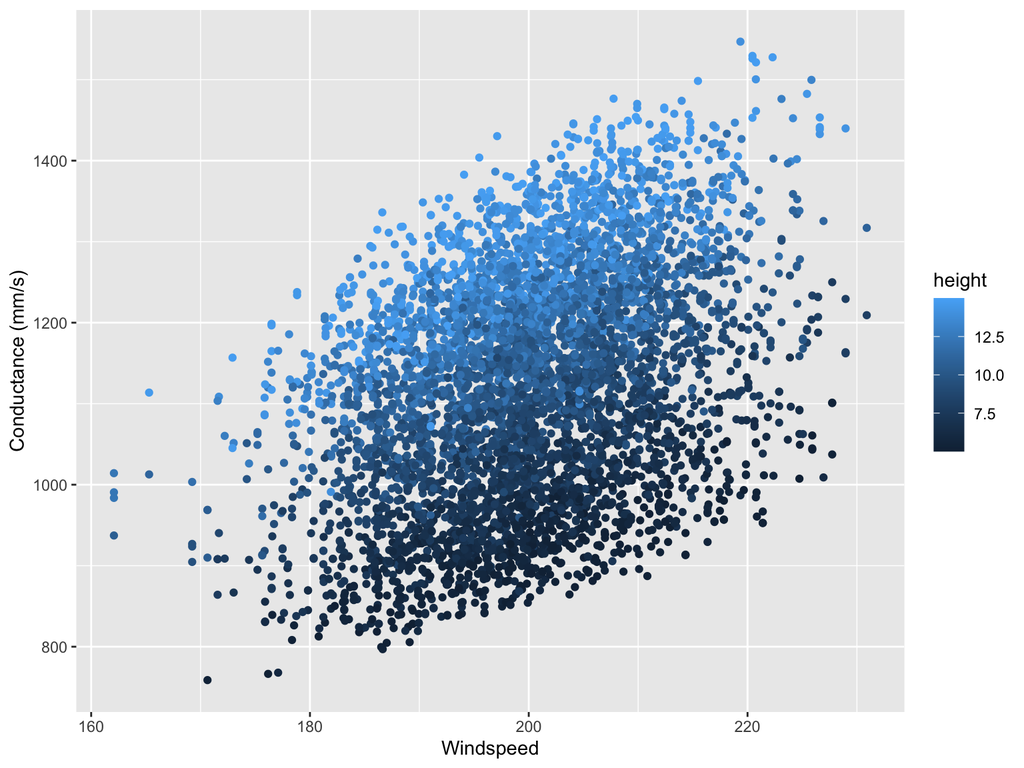

```r
# graph two most sensitive parameters
both = cbind.data.frame(parms, gs=sens_Catm_Sobol$y)

# look at response of conductance to the two most important variables
ggplot(both, aes(v,gs, col=height))+geom_point()+labs(y="Conductance (mm/s)", x="Windspeed")
```

# Some example articles

Snow modeling

Building Cooling Energy Mdoel

Uranium in Groundwater Model

# Second order indices

Optional for this course

If you want to also compute a second order indices you need to use a different variation. (scheme=B)

There are multiple implementation of Sobol in the *senstivity* package, they can be more or less stable I find *sobolSalt* works well

```r
sens_Catm_Sobol2 = sobolSalt(model = NULL, X1, X2, nboot = 100, scheme="B" )

parms = as.data.frame(sens_Catm_Sobol2$X)
colnames(parms)= colnames(X1)
res = pmap_dbl(parms, Catm)


sens_Catm_Sobol2 = sensitivity::tell(sens_Catm_Sobol2,res, res.names="ga")

# main effect:  partitions variance (main effect without co-variance) - sums approximately to one
row.names(sens_Catm_Sobol2$S) = colnames(parms)
sens_Catm_Sobol2$S
```

```
##           original          bias std. error   min. c.i.  max. c.i.
## k_o     0.06845569 -0.0068324158 0.02959620  0.01442004 0.13761145
## k_d    -0.01835728 -0.0066921075 0.03243384 -0.08430582 0.04837495
## v       0.12147111 -0.0064941789 0.02822883  0.06179182 0.18514912
## height  0.75895263 -0.0004551897 0.01182328  0.73962899 0.78864508
```

```r
# total effect - accounts for parameter interactions
row.names(sens_Catm_Sobol2$T) = colnames(parms)
sens_Catm_Sobol2$T
```

[output not shown]

```r
# second order parameters interaction in controlling sensitivity
# parameters are in order, interactiosn are small here
sens_Catm_Sobol2$S2
```

```
##        original        bias std. error   min. c.i.  max. c.i.
## X1X2 0.01828099 0.006649521 0.03245749 -0.04845735 0.08436732
## X1X3 0.02536620 0.007544088 0.03241498 -0.03963127 0.09109278
## X1X4 0.01710633 0.006935333 0.03213991 -0.04854348 0.08040994
## X2X3 0.01843903 0.006676703 0.03249992 -0.04849902 0.08480160
## X2X4 0.01831978 0.006666337 0.03247024 -0.04835828 0.08425642
## X3X4 0.02693459 0.005936970 0.03052898 -0.03922009 0.08787074
```